# Hunting Licenses

Robert Wiederstein

11/14/2020

# 1 Question

# 2 Background

According to an article in Outdoor Life, hunting reached its peak in 1982 when nearly 17 million hunters purchased 28.3 million licenses. Additionally, persons born between the years 1946 and 1964, commonly referred to as the “Baby Boomers”, are the largest cohort of hunters and will age out of the sport in the next 15 years. The decline was acknowledged and projected to continue in Wisconsin deer hunters through 2030. (Winkler and Warnke 2013)

Every five years the National Survey of Fishing, Hunting and Wildlife Associated Recreation is conducted. The last survey in 2016 found that “11.5 million people 16 years and older enjoyed hunting a variety of animals within the United States. They hunted 184 million days and took 147 million trips. Hunting expenditures totaled $26.2 billion.” The survey reported that the national participation rate was four percent with significant regional variation. For example, the New England region had a two percent participation rate while the East South Central region had an eight percent participation rate.

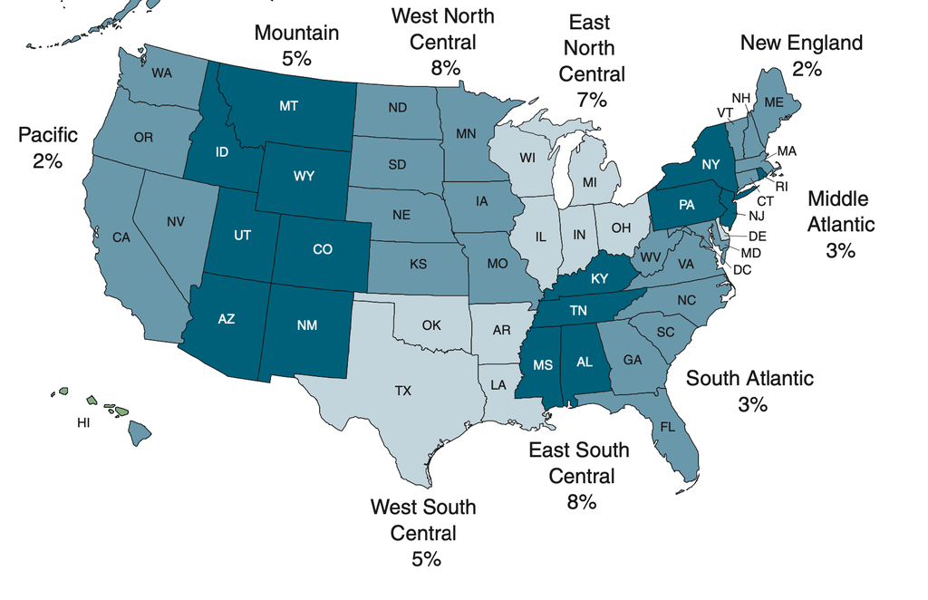

2016 National Survey of Fishing, Hunting, and Wildlife-Associated Recreation, showing regional variation in hunting participation rates.

Various explanations for the decline in hunting have been tendered. Researchers found evidence that more people opt for electronic entertainment and urban living as explainations for the decline in hunting. (Robison and Ridenour 2012)

# 3 Data Sources

Data was retrieved from two sources: the U.S. Fish and Wildlife Agency and the U.S. Census Bureau.

## 3.1 U.S. Fish and Wildlife

States require a hunting license for those harvesting game. People who engage in hunting within the boundaries of the state they reside in require a “resident” hunting license whereas those who travel to another state require a “non-resident” license. A proxy for the popularity of the pastime is the number of hunting licenses issued by the states. The U.S. Fish and Wildlife tracks the issuance of hunting, and fishing, licenses.

Data is available via their [website](https://www.fws.gov/wsfrprograms/Subpages/LicenseInfo/Hunting.htm). Hunting license information is collected annually from (1) state, (2) territory and (3) insular areas license certifications. The data is available for the years 1963 - 2020 though it is in a pdf format.

# 4 Methodology

The effort used a statistical programming language known as “R”. (R Core Team 2019)

```r
file <- "./data_tidy/hunting_licenses_by_state_2000_and_2020.csv"
df <- read.csv(file = file, header = T, colClasses = "character")
str(df)
```

```
## 'data.frame':    900 obs. of  6 variables:
##  $ fips : chr  "01" "02" "04" "05" ...
##  $ state: chr  "Alabama" "Alaska" "Arizona" "Arkansas" ...
##  $ abb  : chr  "AL" "AK" "AZ" "AR" ...
##  $ year : chr  "2000" "2000" "2000" "2000" ...
##  $ key  : chr  "certified_paid_hunting_license_holders_2000" "certified_paid_hunting_license_holders_2000" "certified_paid_hunting_license_holders_2000" "certified_paid_hunting_license_holders_2000" ...
##  $ value: chr  "271865" "97508" "196659" "395304" ...
```

```r
knitr::kable(head(mtcars[, 1:4]), "pipe")
```

|  | mpg | cyl | disp | hp |
| --- | --- | --- | --- | --- |
| Mazda RX4 | 21.0 | 6 | 160 | 110 |
| Mazda RX4 Wag | 21.0 | 6 | 160 | 110 |
| Datsun 710 | 22.8 | 4 | 108 | 93 |
| Hornet 4 Drive | 21.4 | 6 | 258 | 110 |
| Hornet Sportabout | 18.7 | 8 | 360 | 175 |
| Valiant | 18.1 | 6 | 225 | 105 |

```r
knitr::kable(head(mtcars[, 1:4]), "simple")
```

|  | mpg | cyl | disp | hp |
| --- | --- | --- | --- | --- |
| Mazda RX4 | 21.0 | 6 | 160 | 110 |
| Mazda RX4 Wag | 21.0 | 6 | 160 | 110 |
| Datsun 710 | 22.8 | 4 | 108 | 93 |
| Hornet 4 Drive | 21.4 | 6 | 258 | 110 |
| Hornet Sportabout | 18.7 | 8 | 360 | 175 |
| Valiant | 18.1 | 6 | 225 | 105 |

```r
iris2 <- head(iris)
knitr::kable(iris2, col.names = gsub("[.]", " ", names(iris)))
```

| Sepal Length | Sepal Width | Petal Length | Petal Width | Species |
| --- | --- | --- | --- | --- |
| 5.1 | 3.5 | 1.4 | 0.2 | setosa |
| 4.9 | 3.0 | 1.4 | 0.2 | setosa |
| 4.7 | 3.2 | 1.3 | 0.2 | setosa |
| 4.6 | 3.1 | 1.5 | 0.2 | setosa |
| 5.0 | 3.6 | 1.4 | 0.2 | setosa |
| 5.4 | 3.9 | 1.7 | 0.4 | setosa |

```r
# left, center, center, right, right
knitr::kable(iris2,
             align = "lccrr",
             caption = "An example of table caption")
```

An example of table caption

| Sepal.Length | Sepal.Width | Petal.Length | Petal.Width | Species |
| --- | --- | --- | --- | --- |
| 5.1 | 3.5 | 1.4 | 0.2 | setosa |
| 4.9 | 3.0 | 1.4 | 0.2 | setosa |
| 4.7 | 3.2 | 1.3 | 0.2 | setosa |
| 4.6 | 3.1 | 1.5 | 0.2 | setosa |
| 5.0 | 3.6 | 1.4 | 0.2 | setosa |
| 5.4 | 3.9 | 1.7 | 0.4 | setosa |

```r
knitr::kable(iris2, caption = "An example table caption.")
```

An example table caption.

| Sepal.Length | Sepal.Width | Petal.Length | Petal.Width | Species |
| --- | --- | --- | --- | --- |
| 5.1 | 3.5 | 1.4 | 0.2 | setosa |
| 4.9 | 3.0 | 1.4 | 0.2 | setosa |
| 4.7 | 3.2 | 1.3 | 0.2 | setosa |
| 4.6 | 3.1 | 1.5 | 0.2 | setosa |
| 5.0 | 3.6 | 1.4 | 0.2 | setosa |
| 5.4 | 3.9 | 1.7 | 0.4 | setosa |

```r
library(knitr)
library(kableExtra)
kable(iris[1:5, ]) %>%
  kable_styling(latex_options = "striped")
```

| Sepal.Length | Sepal.Width | Petal.Length | Petal.Width | Species |
| --- | --- | --- | --- | --- |
| 5.1 | 3.5 | 1.4 | 0.2 | setosa |
| 4.9 | 3.0 | 1.4 | 0.2 | setosa |
| 4.7 | 3.2 | 1.3 | 0.2 | setosa |
| 4.6 | 3.1 | 1.5 | 0.2 | setosa |
| 5.0 | 3.6 | 1.4 | 0.2 | setosa |

# 5 Conclusions

# 6 Resources

[Krebs, Natalie, Why We Suck at Recruiting New Hunters, Why It Matters, and How You Can Fix It, Outdoor Life (2019).](https://www.outdoorlife.com/why-we-are-losing-hunters-and-how-to-fix-it/)

[U.S. Department of the Interior, U.S. Fish and Wildlife Service, and U.S. Department of Commerce, U.S. Census Bureau. 2016 National Survey of Fishing, Hunting, and Wildlife-Associated Recreation.](https://www.census.gov/content/dam/Census/library/publications/2018/demo/fhw16-nat.pdf)

[Wildlife Management Institute](https://wildlifemanagement.institute).

[Association of Fish and Wildlife Agencies.](https://www.fishwildlife.org)

Sayeed Mehmood, Daowei Zhang & James Armstrong (2003) Factors Associated with Declining Hunting License Sales in Alabama, Human Dimensions of Wildlife, 8:4, 243-262, DOI: 10.1080/716100423

# Bibliography

Mehmood, Sayeed, Daowei Zhang, and James Armstrong. 2003. “Factors Associated with Declining Hunting License Sales in Alabama.” *Human Dimensions of Wildlife* 8 (4). Routledge: 243–62. https://doi.org/10.1080/716100423.

R Core Team. 2019. *R: A Language and Environment for Statistical Computing*. Vienna, Austria: R Foundation for Statistical Computing. https://www.R-project.org.

Robison, Kristopher K., and Daniel Ridenour. 2012. “Whither the Love of Hunting? Explaining the Decline of a Major Form of Rural Recreation as a Consequence of the Rise of Virtual Entertainment and Urbanism.” *Human Dimensions of Wildlife* 17 (6). Routledge: 418–36. https://doi.org/10.1080/10871209.2012.680174.

Rott, Nathan. 2018. “Decline in Hunters Threatens How Us Pays for Conservation.” *National Public Radio*.

Winkler, Richelle, and Keith Warnke. 2013. “The Future of Hunting: An Age-Period-Cohort Analysis of Deer Hunter Decline.” *Population and Environment* 34 (4). Springer: 460–80. https://doi.org/10.1007/s11111-012-0172-6.